# Pitcher card

# Randy Dobnak

RHP · KC

2026 · 15 G (13 GS) · 1,264 pitches · Jul 02 – Sep 24, 2026

Independent portfolio sample by Devin Jenkinson, not affiliated with any club. Every number is computed from public Statcast data.

Three big takeaways

1Attack

The changeup is the put-away pitch. Use it to finish at-bats.

32% of two-strike pitches · 24% whiffs/swing (75 swings)

It grades 92 Stuff+. Next best two-strike miss rate: the sinker at 10%.

2Avoid

Limit the sweeper. It is his most damaging pitch.

xRV/100 -0.41 shrunk (raw -0.95) · .374 xwOBAcon · 313 pitches

When behind in the count he throws it 20% of the time; the changeup grades +0.36 there instead.

3Watch

23% chased on 184 out-of-zone pitches

Fastball height splits are too thin to call (30 swings up, 110 down).

Charts

### Movement

The ST finishes 23 in from his SI, with 23 in more glove-side run.

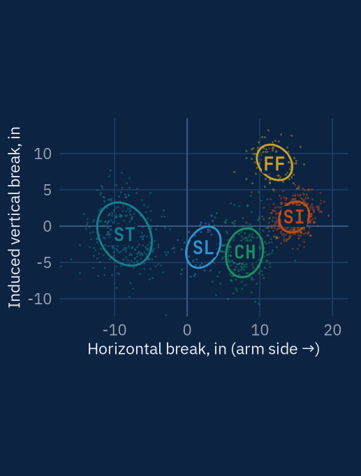

n = 1,264 pitches. Ellipses hold about 68% of each type; codes sit at the averages.

### Location by count

He throws 59% of pitches in the zone when behind and 35% when ahead.

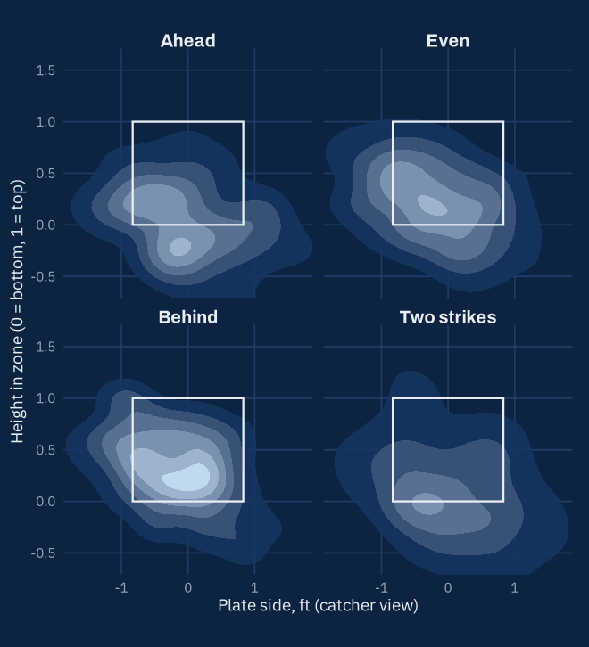

n = 1,264. Ahead 159 · even 451 · behind 303 · two strikes 351 pitches. Box = rule-book zone.

### Put-away

The CH is 32% of two-strike pitches vs 22% overall.

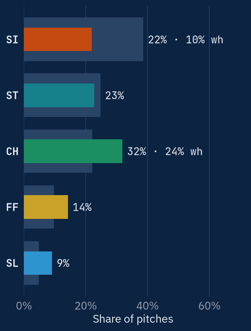

Two-strike n: CH 112, ST 80, SI 77, FF 50, SL 32. Grey bars = overall usage; wh = whiffs per swing (shown with 50+ swings).

### Arsenal

| Pitch | # | Use | Velo | IVB | HB | VAA | Whiff | Chase | xwOBAcon | xRV/100 | Stuff+ |
| --- | --- | --- | --- | --- | --- | --- | --- | --- | --- | --- | --- |
| Sinker (SI) | 488 | 39% | 91.5 | 1.3 | +14.7 | -6.6 | 7% | 18% | .375 | +0.23 | 93 |
| Sweeper (ST) | 313 | 25% | 82.4 | -1.1 | -8.6 | -7.8 | 32% | 23% | .374 | -0.41 | 92 |
| Changeup (CH) | 279 | 22% | 84.7 | -3.5 | +8.0 | -8.1 | 28% | 47% | .349 | +0.36 | 92 |
| 4-Seam (FF) | 122 | 10% | 92.2 | 8.6 | +12.0 | -5.1 | 12% | 21% | .276 | -0.31 | 71 |
| Slider (SL) | 62 | 5% | 83.7 | -2.9 | +2.2 | -8.4 | 29% | 40% | .380 | -0.22 | 88 |

IVB / HB in inches (HB + = arm side). VAA in degrees at the front of the plate. xRV/100 = expected run value per 100 pitches, pitcher’s view, shrunk with a 250-pitch prior. Stuff+ = this project’s shape-only model (100 = MLB average, 10 = 1 SD).

### Vs. batter hand

| Pitch | LHH # | Use | Whiff | xwOBAcon | RHH # | Use | Whiff | xwOBAcon |
| --- | --- | --- | --- | --- | --- | --- | --- | --- |
| SI | 273 | 35% | 5% | .404 | 215 | 45% | 11% | .363 |
| ST | 143 | 18% | – | .428 | 170 | 35% | 35% | .297 |
| CH | 223 | 28% | 27% | .270 | 56 | 12% | – | .250 |
| FF | 100 | 13% | – | .244 | 22 | 5% | – | .383 |
| SL | 44 | 6% | – | .306 | 18 | 4% | – | .215 |

Use = share of pitches to that side. Whiff = whiffs per swing, shown with 50+ swings.